# Presentación del proyecto

2025-08-08

## Introducción

Al revisar las bases de datos disponibles en Gapminder, encontré una gran variedad de información relacionada con las mujeres, lo que despertó en mí una inquietud sobre la posible relación entre la longevidad femenina y la maternidad.

A mis 35 años, nunca había considerado que la decisión de tener hijos pudiera estar vinculada con la longevidad.

## Objetivo General

1. Explorar la posible relación entre la esperanza de vida femenina, la fecundidad y el nivel de desarrollo económico en países del mundo, a partir de datos históricos entre 1950 y 2021 disponibles en Gapminder.

**Objetivos específicos son**

1. Analizar patrones y tendencias en la relación entre esperanza de vida femenina y número promedio de hijos por mujer, identificando posibles asociaciones según región geográfica y a lo largo del tiempo.
2. Explorar la relación entre el producto interno bruto per cápita (ajustado por poder adquisitivo) y los niveles de fecundidad y longevidad femenina, para determinar si existen diferencias significativas entre países con distinto nivel de desarrollo económico.

## Extracción de Datos

Disponibles en Gapminder para desarrollar un análisis exploratorio de datos:

• Life_expectancy_female: esperanza de vida al nacer de mujeres (en años).

• Children_per_women_total_fertility: número promedio de hijos por mujer a lo largo de su vida.

• Gross domestic product per person: producto interno bruto per cápita ajustado por paridad de poder adquisitivo al año 2021.

## Construcción del Dashboard

En la primera sección del dashboard, el objetivo era ofrecer una visión general de las tres variables principales.

La segunda sección, dedicada a los gráficos comparativos de variables, presenta tres gráficos de dispersión con distintos colores, lo que facilita su diferenciación. En la tercera sección, correspondiente a los gráficos de interacción avanzada, se representa la relación entre las tres variables mediante un gráfico de dispersión.

## Resultados Generales

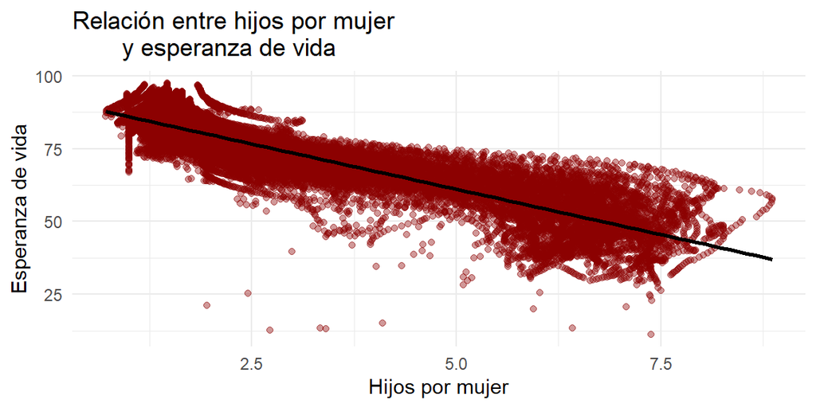

## Algunas excepciones

Algunos países con 1 o 2 hijos mantienen niveles altos de esperanza de vida, lo que indica que no se puede afirmar de forma categórica que tener menos hijos siempre incrementa la longevidad.

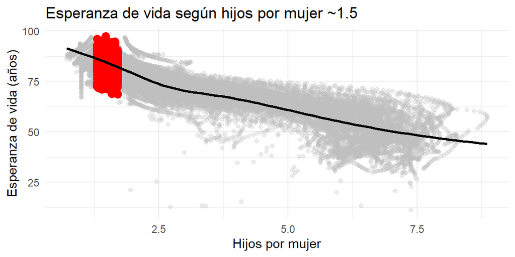

## A nivel Regional: Europa

Se observa una caída en la cantidad de hijos por mujeres y con esto también el aumento de la esperanza de vida en países con 2 hijos por mujer, aunque no se trata de una reducción sistemática. De hecho, varios países con solo 1 hijo muestran menor esperanza de vida que aquellos con 2, lo cual podría deberse a factores contextuales como el envejecimiento poblacional o las políticas de salud.

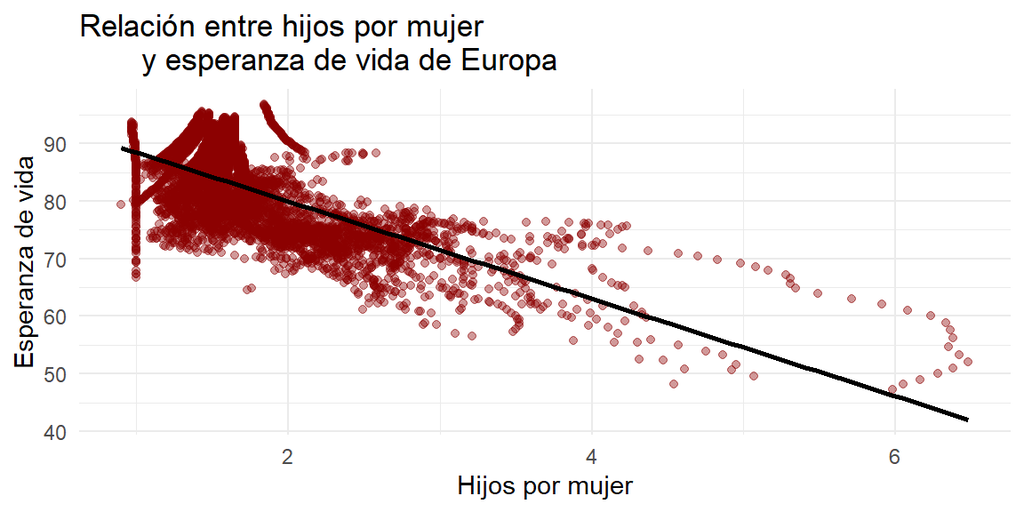

## A nivel Regional: África

Se registra la esperanza de vida más baja en comparación con otros continentes, manteniéndose la tendencia decreciente a pesar de una alta fecundidad.

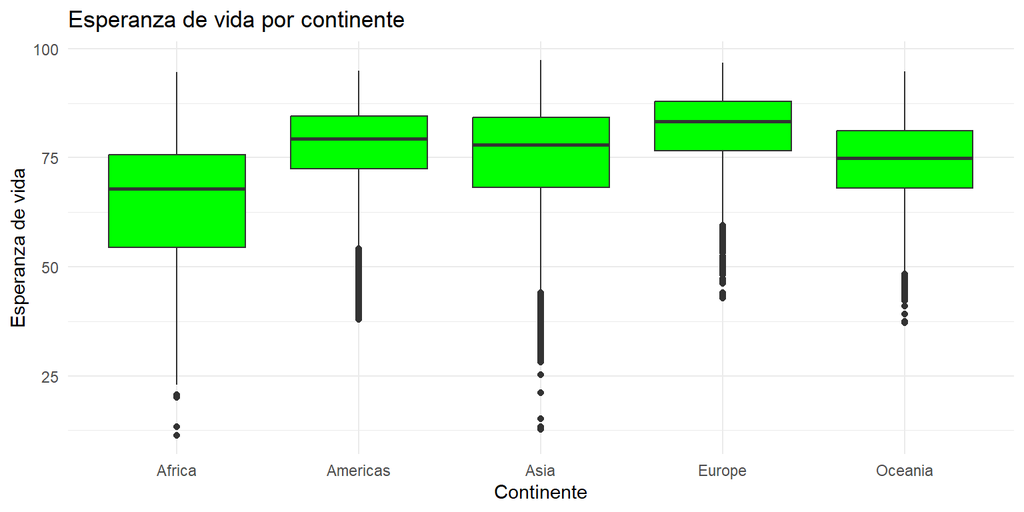

## A nivel Regional: África

En esta región, el bajo nivel del PIB per cápita también resalta como un elemento que podría influir en los resultados, reflejando bajos niveles de desarrollo económico.

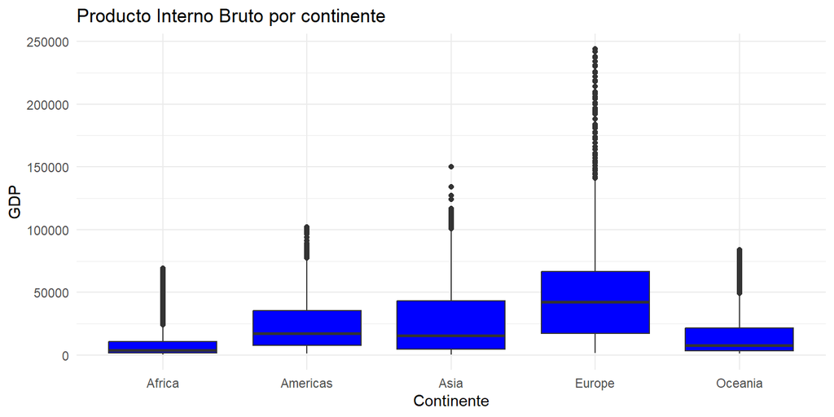

## A nivel Regional: Áméricas

Se conserva la tendencia general: los países con mayor fecundidad tienden a registrar niveles más bajos de esperanza de vida. Este patrón refuerza la hipótesis de una correlación negativa entre estas dos variables, aunque no necesariamente causal.

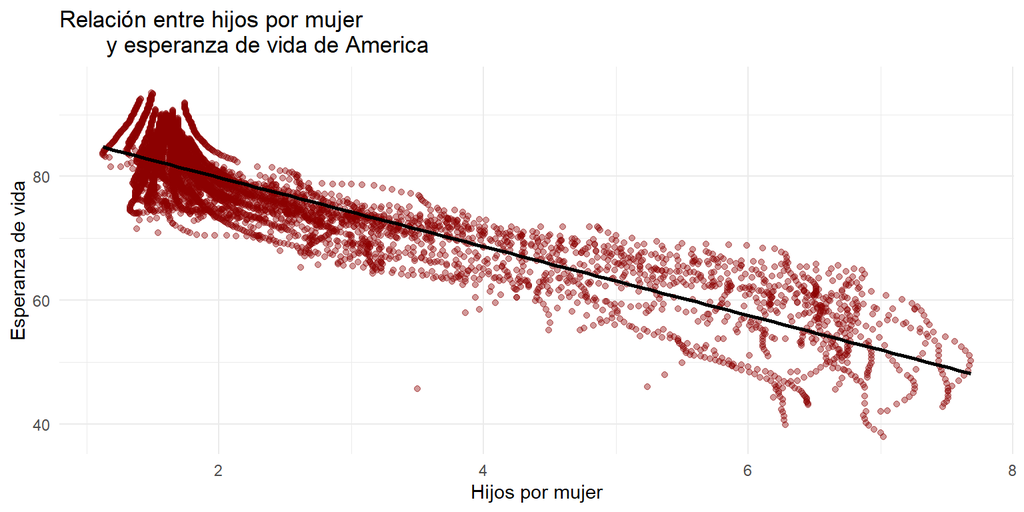

## Interacción Avanzada: GDP, esperanza de vida y cantidad de hijos

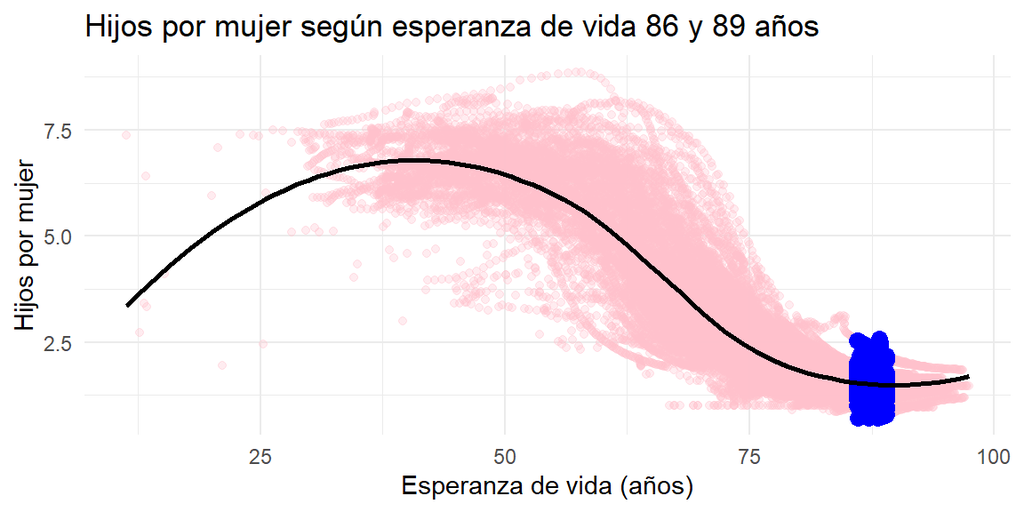

## Interacción Avanzada: GDP, esperanza de vida y cantidad de hijos

Los países con una fecundidad de 1 hijo muestran una esperanza de vida aún mayor, entre 93 y 96 años. No puede afirmarse que a menor número de hijos por mujer siempre corresponda una mayor esperanza de vida.

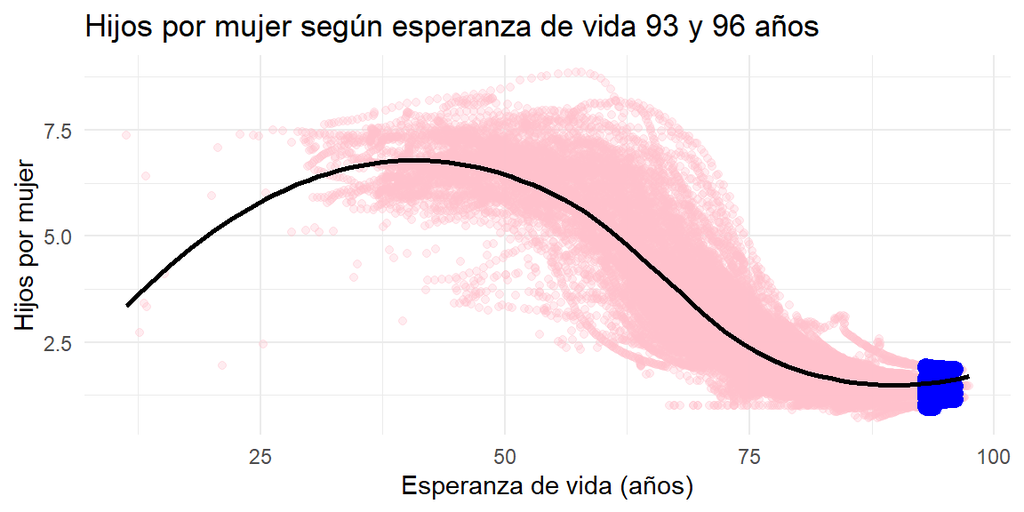

## Características de la investigación

Los datos analizados provienen de una investigación exploratoria con información agregada a nivel país, por lo que no permiten establecer relaciones causales individuales.

Aunque no se puede concluir que tener hijos necesariamente alarga o acorta la vida, los gráficos permiten identificar tendencias consistentes, especialmente al analizar los datos por regiones o niveles de desarrollo económico.

## Producto Interno Bruto

Se observa que los países con PIB superiores a 100,000 dólares se ubican principalmente en la franja de 2 a 2.5 hijos por mujer, y presentan una esperanza de vida alta.

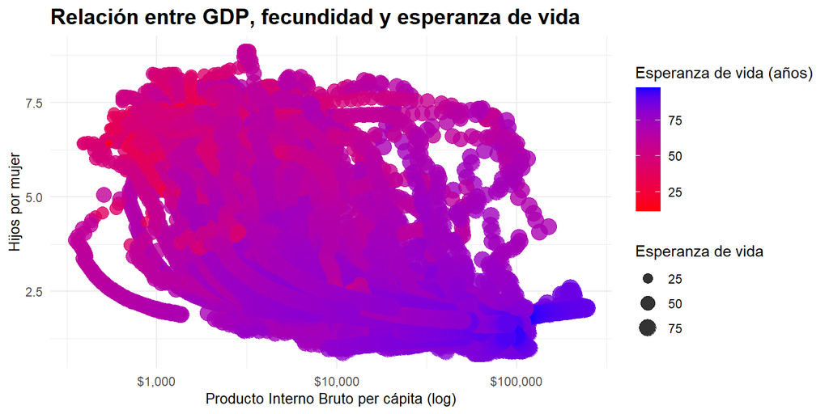

## Eje Temporal: 1970

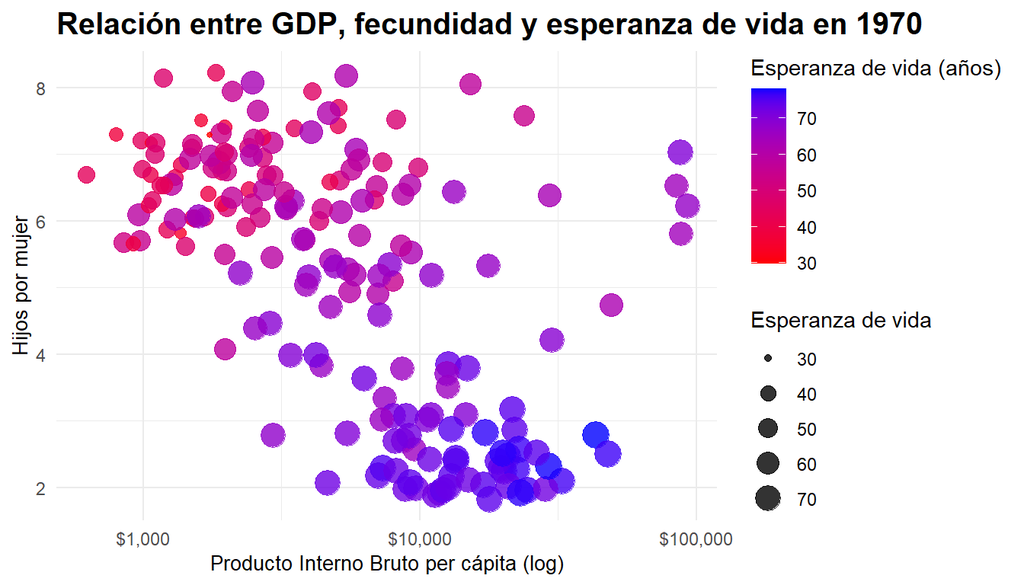

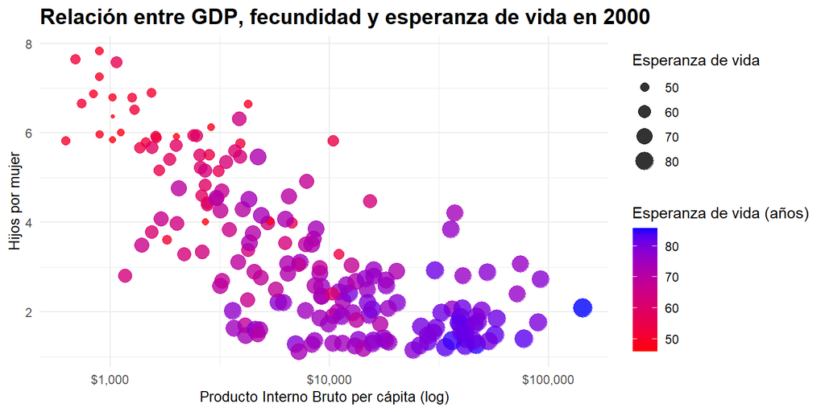

## Ideas Finales

Aunque la fecundidad no es un determinante único en la decisión de tener hijos ni en la esperanza de vida, constituye un elemento relevante en el análisis con perspectiva de género, ya que las decisiones reproductivas están influenciadas por factores sociales, económicos y culturales.

Los datos permiten identificar patrones generales entre esperanza de vida, fecundidad y nivel de desarrollo económico. En el futuro, podrían desarrollarse modelos predictivos que, tomando en cuenta el número de hijos y el nivel económico, estimen la esperanza de vida de las mujeres.